# Beschreibende Statistik mit R

## 5.4 Fehlerbalken

Wir berechnen den Mittelwert und die Standardabweichung und nutzen diese Werte in der grafischen Ausgabe.

```
`fun.y` is deprecated. Use `fun` instead.
```

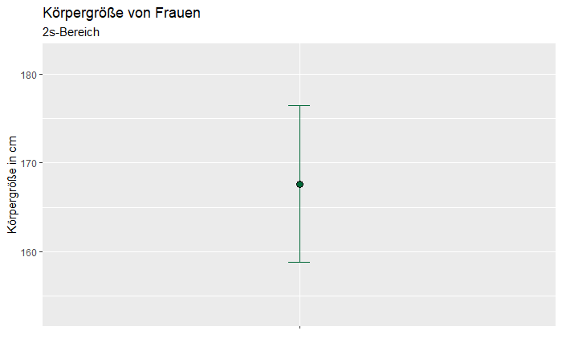

```r
kennzahlen <- frauen %>%
  summarize(mw = mean(Koerpergroesse),
            stdabw = sd(Koerpergroesse)
            )

ggplot(frauen, aes(x="", y=Koerpergroesse)) +
  geom_errorbar(aes(ymin=kennzahlen$mw-kennzahlen$stdabw,
                    ymax=kennzahlen$mw+kennzahlen$stdabw),
                 color = myPalette[5],
                 width=0.05,
                 size=0.5) +
  stat_summary(fun.y = "mean", geom= "point",
               size = 3, shape = 21, fill=myPalette[5]) +
  theme(axis.title.x = element_blank()) +
  labs(
    title="Körpergröße von Frauen",
    subtitle="2s-Bereich",
    y="Körpergröße in cm"
  )
```

Wir können Fehlerbalken und Box-Plots auch einer Grafik zusammenfassen:

```
`fun.y` is deprecated. Use `fun` instead.
```

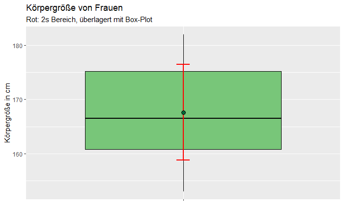

```r
ggplot(frauen, aes(x="", y=Koerpergroesse)) +
    geom_boxplot(fill=myPalette[3], color="black") +
    geom_errorbar(aes(ymin=kennzahlen$mw-kennzahlen$stdabw,
                    ymax=kennzahlen$mw+kennzahlen$stdabw),
                 color = "red",
                 width=0.05,
                 size=0.75) +
  stat_summary(fun.y = "mean", geom= "point",
               size = 3, shape = 21, fill=myPalette[5]) +
  theme(axis.title.x = element_blank()) +
  labs(
    title="Körpergröße von Frauen",
    subtitle="Rot: 2s Bereich, überlagert mit Box-Plot",
    y="Körpergröße in cm"
  )
```

## 5.5 Histogramme

Für dieses Thema verwenden wir den Datensatz *Körpergröße von Frauen*. Wir erstellen wieder Tabellen für die absolute und relative Häufigkeiten.

```r
tally(frauen)
```

| n |
| --- |
| 24 |

```r
frequencies <- frauen %>%
  group_by(Koerpergroesse) %>%
  summarize(n=n()) %>%
  mutate(relativ = n / sum(n),
         prozent = relativ*100)

frequencies
```

| Koerpergroesse | n | relativ | prozent |
| --- | --- | --- | --- |
| 153 | 1 | 0.0417 | 4.17 |
| 154 | 1 | 0.0417 | 4.17 |
| 158 | 1 | 0.0417 | 4.17 |
| 159 | 2 | 0.0833 | 8.33 |
| 160 | 1 | 0.0417 | 4.17 |
| 161 | 2 | 0.0833 | 8.33 |
| 162 | 1 | 0.0417 | 4.17 |
| 163 | 1 | 0.0417 | 4.17 |
| 165 | 1 | 0.0417 | 4.17 |
| 166 | 1 | 0.0417 | 4.17 |

[output cut: 10 more lines]

In beiden Ausgaben sehen wir gut, dass wir nur sehr kleine Werte von Häufigkeiten für relativ viele Merkmalsausprägungen erhalten. Wir erstellen ein Balkendiagramm, das das gleiche Problem illustriert. Das Merkmal im Datensatz hat den Namen *Koerpergroesse*. Die x-Achse ist jetzt kontinuierlich, deshalb verwenden wir für diese Achse die Funktion *scale_x_continuous(limits=c(150.0, 185.0))*. Damit legen wir den minimalen und maximalen Wert für die Achse in der grafischen Ausgabe fest.

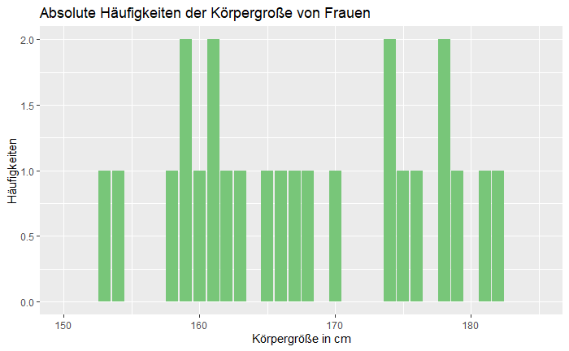

```r
ggplot(frauen)  +
  geom_bar(mapping=aes(x=Koerpergroesse),
           fill=myPalette[3]) +
  scale_x_continuous(limits=c(150.0, 185.0)) +
  labs(
    title="Absolute Häufigkeiten der Körpergroße von Frauen",
    x="Körpergröße in cm",
    y="Häufigkeiten"
  )
```

Wir bilden Klassen und stellen ein Histogramm dar. Dazu gibt es im Package *ggplot2* die Funktion *geom_histogram*. Für die Farbe der Balken können wir eine Füllfarbe und eine Randfarbe angeben. Für die Füllfarbe wählen wir wie bisher eine Farbe aus unserer Palette, für den Rand wählen wir Schwarz, um die einzelnen Balken optisch zu trennen. Bei der Konstruktion der Partition müssen wir uns immer entscheiden, ob die verwendeten Intervalle an den Grenzen, an denen die Intervall aneinanderstoßen links oder rechts offen sind. Das können wir *geom_histogram* mit der Option *closed=“left”* übergeben. Diese Auswahl entspricht der Vereinbarung aus der Stochastik-Vorlesung.

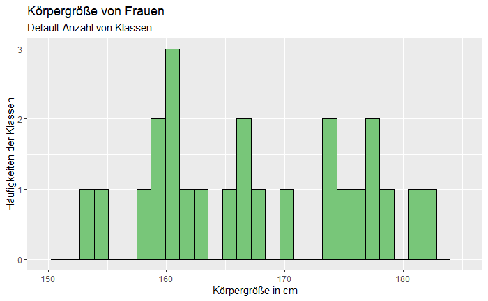

```r
ggplot(frauen) +
  geom_histogram(mapping=aes(x=Koerpergroesse), closed="left",
          fill=myPalette[3], color="black") +
  scale_x_continuous(limits=c(150.0, 185.0)) +
  labs(
    title="Körpergröße von Frauen",
    subtitle="Default-Anzahl von Klassen",
    x="Körpergröße in cm",
    y="Häufigkeiten der Klassen"
  )
```

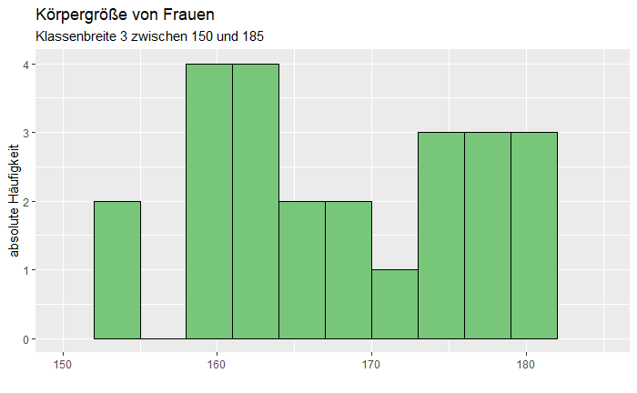

```r
ggplot(frauen) +
  geom_histogram(mapping=aes(x=Koerpergroesse), closed="left",
          breaks=seq(152.0, 182.0, 3.0),
          fill=myPalette[3], color="black") +
  scale_x_continuous(limits=c(150.0, 185.0)) +
  labs(
    title="Körpergröße von Frauen",
    subtitle="Klassenbreite 3 zwischen 150 und 185",
    x="",
    y="absolute Häufigkeit"
  )
```

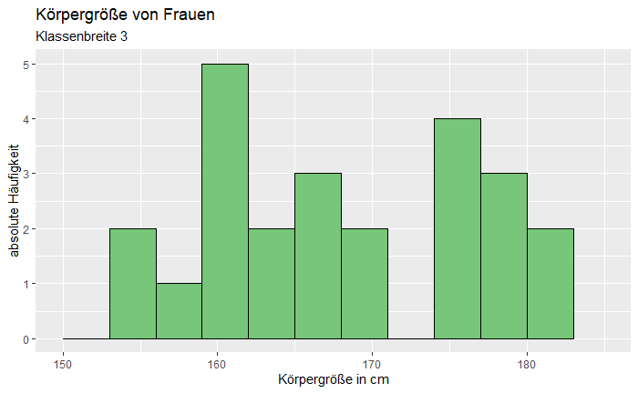

```r
ggplot(frauen) +
  geom_histogram(mapping=aes(x=Koerpergroesse), closed="left",
          binwidth=3.0, boundary=0,
          fill=myPalette[3],
          color="black") +
  scale_x_continuous(limits=c(150.0, 185.0)) +
  labs(
    title="Körpergröße von Frauen",
    subtitle="Klassenbreite 3",
    x="Körpergröße in cm",
    y="absolute Häufigkeit"
  )
```

Bevor wir noch weitere Klassenbreiten verwenden geben wir die Klassenhäufigkeiten in einer Tabelle aus. Dazu verwenden wir das Package *Tidyverse*:

```r
klassen <- frauen %>%
  count(cut_width(
    Koerpergroesse, width=3.0, boundary=0, closed="left")
  )
klassen
```

| cut_width(Koerpergroesse, width = 3, boundary = 0, closed = "left") | n |
| --- | --- |
| [153,156) | 2 |
| [156,159) | 1 |
| [159,162) | 5 |
| [162,165) | 2 |
| [165,168) | 3 |
| [168,171) | 2 |
| [174,177) | 4 |
| [177,180) | 3 |
| [180,183] | 2 |

Die Klassen sind Elemente vom Typ *factor*, was Sie nicht überraschen sollte.

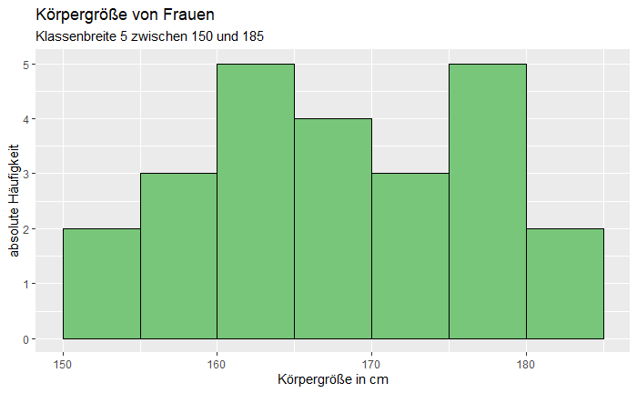

```r
min = 150.0
max = 185.0
delta = 5.0
ggplot(frauen) +
  geom_histogram(mapping=aes(x=Koerpergroesse),
                 closed="left",
          breaks=seq(min, max, delta),
          fill=myPalette[3], color="black") +
  scale_x_continuous(limits=c(150.0, 185.0)) +
  labs(
    title="Körpergröße von Frauen",
    subtitle="Klassenbreite 5 zwischen 150 und 185",
    x="Körpergröße in cm",
    y="absolute Häufigkeit"
  )
```

# 6 Literaturverzeichnis

Benesch, Thomas. 2013. *Schlüsselkonzepte Zur Statistik*. Springer Spektrum.

Günter Bamberg, Franz Baur. 1993. *Statistik*. 8. ed. Oldenbourg.